# Midterm 2 W24

Itzel Barrios

2024-02-27

## Instructions

Answer the following questions and complete the exercises in RMarkdown. Please embed all of your code and push your final work to your repository. Your code must be organized, clean, and run free from errors. Remember, you must remove the `#` for any included code chunks to run. Be sure to add your name to the author header above.

Your code must knit in order to be considered. If you are stuck and cannot answer a question, then comment out your code and knit the document. You may use your notes, labs, and homework to help you complete this exam. Do not use any other resources- including AI assistance.

Don’t forget to answer any questions that are asked in the prompt. Some questions will require a plot, but others do not- make sure to read each question carefully.

For the questions that require a plot, make sure to have clearly labeled axes and a title. Keep your plots clean and professional-looking, but you are free to add color and other aesthetics.

Be sure to follow the directions and upload your exam on Gradescope.

## Background

In the `data` folder, you will find data about shark incidents in California between 1950-2022. The [data](https://catalog.data.gov/dataset/shark-incident-database-california-56167) are from: State of California- Shark Incident Database.

## Load the libraries

```r
library("tidyverse")
library("janitor")
library("naniar")
```

## Load the data

Run the following code chunk to import the data.

```r
sharks <- read_csv("data/SharkIncidents_1950_2022_220302.csv") %>% clean_names()
```

## Questions

1. (1 point) Start by doing some data exploration using your preferred function(s). What is the structure of the data? Where are the missing values and how are they represented?

```r
glimpse(sharks)
```

```
## Rows: 211
## Columns: 16
## $ incident_num     <chr> "1", "2", "3", "4", "5", "6", "7", "8", "9", "10", "1…
## $ month            <dbl> 10, 5, 12, 2, 8, 4, 10, 5, 6, 7, 10, 11, 4, 5, 5, 8, …
## $ day              <dbl> 8, 27, 7, 6, 14, 28, 12, 7, 14, 28, 4, 10, 24, 19, 21…
## $ year             <dbl> 1950, 1952, 1952, 1955, 1956, 1957, 1958, 1959, 1959,…
## $ time             <chr> "12:00", "14:00", "14:00", "12:00", "16:30", "13:30",…
## $ county           <chr> "San Diego", "San Diego", "Monterey", "Monterey", "Sa…
## $ location         <chr> "Imperial Beach", "Imperial Beach", "Lovers Point", "…
## $ mode             <chr> "Swimming", "Swimming", "Swimming", "Freediving", "Sw…
## $ injury           <chr> "major", "minor", "fatal", "minor", "major", "fatal",…
## $ depth            <chr> "surface", "surface", "surface", "surface", "surface"…
## $ species          <chr> "White", "White", "White", "White", "White", "White",…
## $ comment          <chr> "Body Surfing, bit multiple times on leg, thigh and b…
## $ longitude        <chr> "-117.1466667", "-117.2466667", "-122.05", "-122.15",…
## $ latitude         <dbl> 32.58833, 32.58833, 36.62667, 36.62667, 35.13833, 35.…
## $ confirmed_source <chr> "Miller/Collier, Coronado Paper, Oceanside Paper", "G…
## $ wfl_case_number  <chr> NA, NA, NA, NA, NA, NA, NA, NA, NA, NA, NA, NA, NA, N…
```

```r
sharks%>% naniar::miss_var_summary()
```

```
## # A tibble: 16 × 3
##    variable         n_miss pct_miss
##    <chr>             <int>    <dbl>
##  1 wfl_case_number     202   95.7
##  2 time                  7    3.32
##  3 latitude              6    2.84
##  4 longitude             5    2.37
##  5 confirmed_source      1    0.474
##  6 incident_num          0    0
##  7 month                 0    0
##  8 day                   0    0
##  9 year                  0    0
## 10 county                0    0
## 11 location              0    0
## 12 mode                  0    0
## 13 injury                0    0
## 14 depth                 0    0
## 15 species               0    0
## 16 comment               0    0
```

```r
anyNA(sharks)
```

```
## [1] TRUE
```

2. (1 point) Notice that there are some incidents identified as “NOT COUNTED”. These should be removed from the data because they were either not sharks, unverified, or were provoked. It’s OK to replace the `sharks` object.

```r
new_sharks <- sharks%>%
  filter(incident_num!="NOT COUNTED")
new_sharks
```

```
## # A tibble: 202 × 16
##    incident_num month   day  year time    county     location mode  injury depth
##    <chr>        <dbl> <dbl> <dbl> <chr>   <chr>      <chr>    <chr> <chr>  <chr>
##  1 1               10     8  1950 12:00   San Diego  Imperia… Swim… major  surf…
##  2 2                5    27  1952 14:00   San Diego  Imperia… Swim… minor  surf…
##  3 3               12     7  1952 14:00   Monterey   Lovers … Swim… fatal  surf…
##  4 4                2     6  1955 12:00   Monterey   Pacific… Free… minor  surf…
##  5 5                8    14  1956 16:30   San Luis … Pismo B… Swim… major  surf…
##  6 6                4    28  1957 13:30   San Luis … Morro B… Swim… fatal  surf…
##  7 7               10    12  1958 Unknown San Diego  Coronad… Swim… major  surf…
##  8 8                5     7  1959 17:30   San Franc… Baker B… Swim… fatal  surf…
##  9 9                6    14  1959 17:00   San Diego  La Jolla Free… fatal  surf…
## 10 10               7    28  1959 19:30   San Diego  La Jolla Free… minor  surf…
## # ℹ 192 more rows
## # ℹ 6 more variables: species <chr>, comment <chr>, longitude <chr>,
## #   latitude <dbl>, confirmed_source <chr>, wfl_case_number <chr>
```

3. (3 points) Are there any “hotspots” for shark incidents in California? Make a plot that shows the total number of incidents per county. Which county has the highest number of incidents?

```r
new_sharks%>%
  group_by(incident_num, county, location)%>%
  count(incident_num)%>%
  arrange(desc(incident_num))
```

```
## # A tibble: 202 × 4
## # Groups:   incident_num, county, location [202]
##    incident_num county     location                                n
##    <chr>        <chr>      <chr>                               <int>
##  1 99           Sonoma     "Salmon Creek Beach"                    1
##  2 98           Humboldt   "Moonstone Beach"                       1
##  3 97           Marin      "Stinson Beach, off Bolinas Lagoon"     1
##  4 95           Humboldt   "\"Bunkers\", Eureka"                   1
##  5 94           San Mateo  "Half Moon Bay, Pillar Point"           1
##  6 93           Santa Cruz "Waddell Reef"                          1
##  7 92           Marin      "Stinson Beach"                         1
##  8 91           Humboldt   "Moonstone Beach"                       1
##  9 90           Sonoma     "Salmon Creek Beach"                    1
## 10 9            San Diego  "La Jolla"                              1
## # ℹ 192 more rows
```

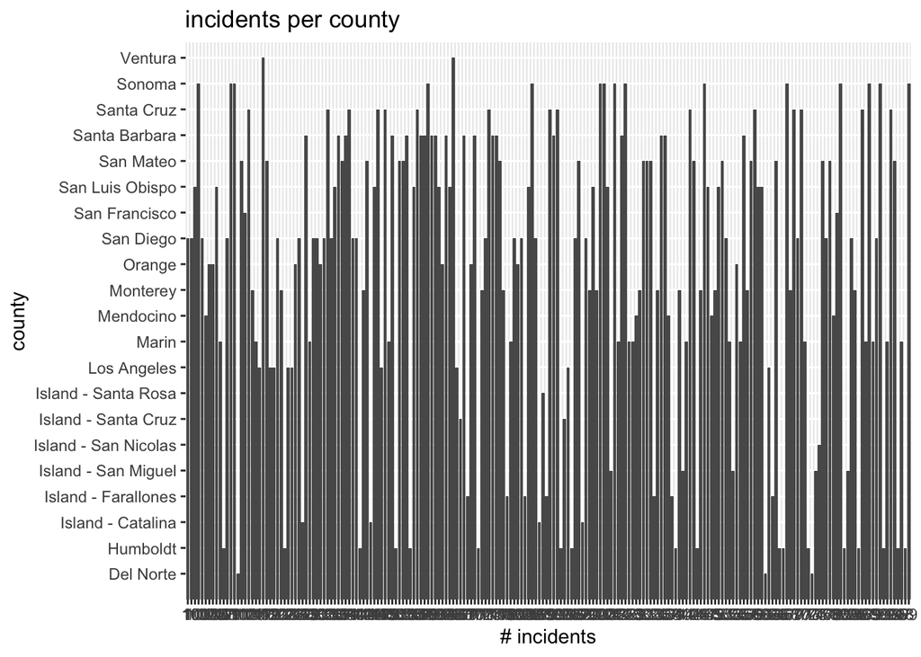

```r
new_sharks%>%
  ggplot(aes(x=incident_num, y=county))+
  geom_col()+
  geom_smooth(method=lm, se=F)+
  labs(title = "incidents per county",
       x="# incidents",
       y="county")
```

4. (3 points) Are there months of the year when incidents are more likely to occur? Make a plot that shows the total number of incidents by month. Which month has the highest number of incidents?

```r
new_sharks%>%
  group_by(incident_num, month)%>%
  count(incident_num)%>%
  arrange(desc(incident_num))
```

```
## # A tibble: 202 × 3
## # Groups:   incident_num, month [202]
##    incident_num month     n
##    <chr>        <dbl> <int>
##  1 99              11     1
##  2 98               9     1
##  3 97               5     1
##  4 95              11     1
##  5 94               9     1
##  6 93              11     1
##  7 92               8     1
##  8 91               8     1
##  9 90              11     1
## 10 9                6     1
## # ℹ 192 more rows
```

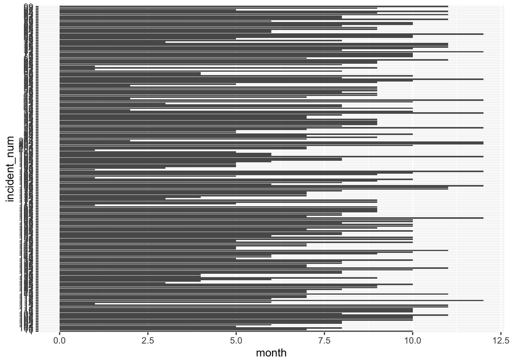

```r
new_sharks%>%
  group_by(incident_num, month)%>%
  ggplot(aes(x=incident_num, y=month))+
  geom_col()+
  coord_flip()
```

```r
  geom_smooth(method=lm, se=F)
```

[output not shown]

[output cut: 9 more lines]

[output not shown]

5. (3 points) How do the number and types of injuries compare by county? Make a table (not a plot) that shows the number of injury types by county. Which county has the highest number of fatalities?

```r
new_sharks%>%
  group_by(incident_num, injury, county)%>%
  tabyl(injury, county)
```

```
##  injury Del Norte Humboldt Island - Catalina Island - Farallones
##   fatal         0        0                 0                   0
##   major         0        7                 0                   7
##   minor         2        2                 1                   0
##    none         1        9                 3                   0
##  Island - San Miguel Island - San Nicolas Island - Santa Cruz
##                    1                    0                   0
##                    2                    0                   0
##                    2                    1                   1
##                    0                    0                   1
##  Island - Santa Rosa Los Angeles Marin Mendocino Monterey Orange San Diego
##                    0           1     0         1        2      0         2
##                    1           0     9         3        8      1         4
##                    0           6     4         1        2      2         8
##                    0           2     3         0        3      5         9
##  San Francisco San Luis Obispo San Mateo Santa Barbara Santa Cruz Sonoma
##              1               3         1             2          1      0
##              0               3         1             2          3      8
##              0               1         4             6          3      1
##              1               7        12             9          8      6
##  Ventura
##        0
##        0
##        2
##        0
```

```r
new_sharks%>%
  filter(injury=="fatal")%>%
  group_by(injury, county)%>%
  count(injury)%>%
  arrange(desc(injury))
```

```
## # A tibble: 10 × 3
## # Groups:   injury, county [10]
##    injury county                  n
##    <chr>  <chr>               <int>
##  1 fatal  Island - San Miguel     1
##  2 fatal  Los Angeles             1
##  3 fatal  Mendocino               1
##  4 fatal  Monterey                2
##  5 fatal  San Diego               2
##  6 fatal  San Francisco           1
##  7 fatal  San Luis Obispo         3
##  8 fatal  San Mateo               1
##  9 fatal  Santa Barbara           2
## 10 fatal  Santa Cruz              1
```

6. (2 points) In the data, `mode` refers to a type of activity. Which activity is associated with the highest number of incidents?

```r
new_sharks%>%
  group_by(incident_num, mode)%>%
  count(incident_num)%>%
  arrange(desc(incident_num))
```

```
## # A tibble: 202 × 3
## # Groups:   incident_num, mode [202]
##    incident_num mode                   n
##    <chr>        <chr>              <int>
##  1 99           Surfing / Boarding     1
##  2 98           Surfing / Boarding     1
##  3 97           Surfing / Boarding     1
##  4 95           Surfing / Boarding     1
##  5 94           Surfing / Boarding     1
##  6 93           Surfing / Boarding     1
##  7 92           Surfing / Boarding     1
##  8 91           Surfing / Boarding     1
##  9 90           Surfing / Boarding     1
## 10 9            Freediving             1
## # ℹ 192 more rows
```

7. (4 points) Use faceting to make a plot that compares the number and types of injuries by activity. (hint: the x axes should be the type of injury)

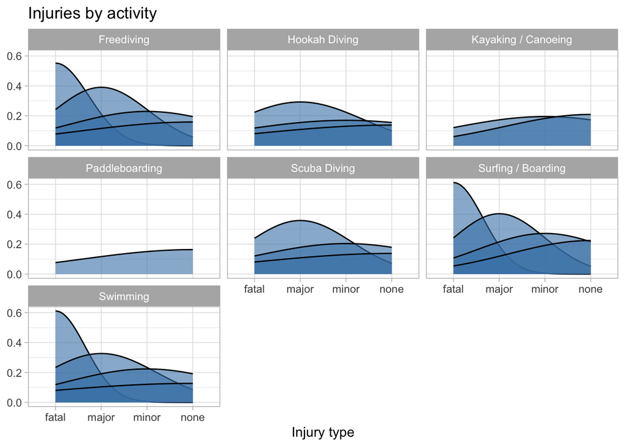

```r
new_sharks%>%
  ggplot(aes(x=injury))+
  geom_density(fill="steelblue", color="black", alpha=0.6, na.rm=F)+
  facet_wrap(~mode)+
  labs(title="Injuries by activity", x="Injury type", y=NULL)+
  theme_light()
```

8. (1 point) Which shark species is involved in the highest number of incidents?

```r
new_sharks%>%
  group_by(species, incident_num)%>%
  count(incident_num)%>%
  arrange(desc(incident_num))
```

```
## # A tibble: 202 × 3
## # Groups:   species, incident_num [202]
##    species incident_num     n
##    <chr>   <chr>        <int>
##  1 White   99               1
##  2 White   98               1
##  3 White   97               1
##  4 White   95               1
##  5 White   94               1
##  6 White   93               1
##  7 White   92               1
##  8 White   91               1
##  9 White   90               1
## 10 White   9                1
## # ℹ 192 more rows
```

9. (3 points) Are all incidents involving Great White’s fatal? Make a plot that shows the number and types of injuries for Great White’s only.

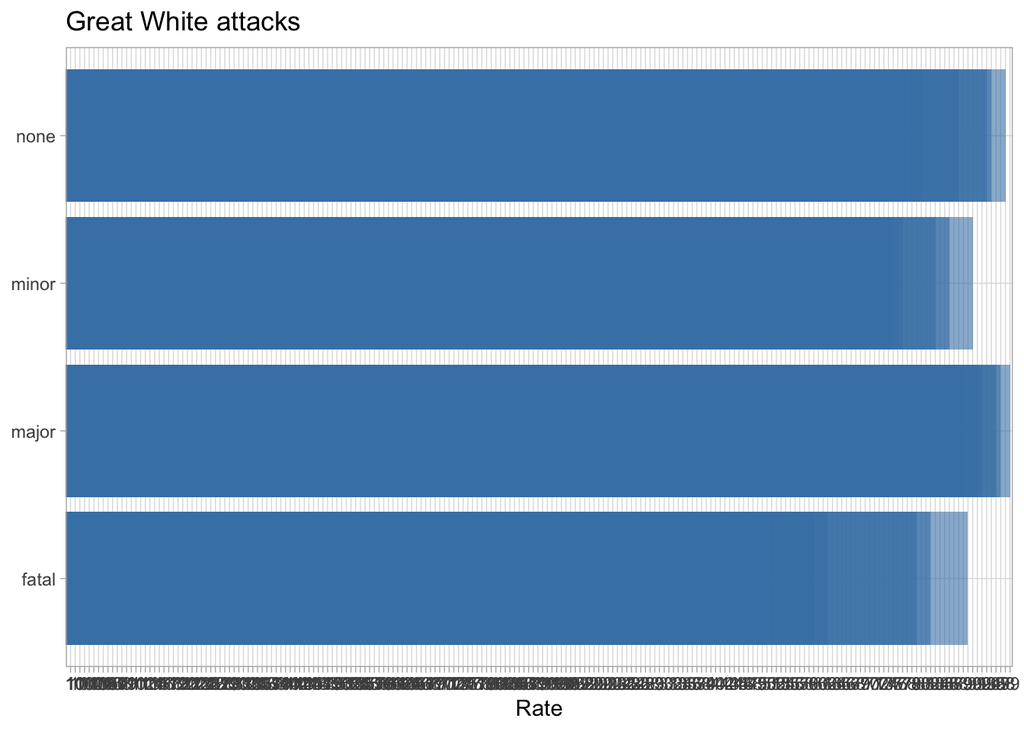

```r
new_sharks%>%
  group_by(injury, incident_num)%>%
  ggplot(aes(x=injury, y=incident_num, group=injury))+
  geom_col(position="dodge", fill="steelblue", alpha=0.6)+
  coord_flip()+
  labs(title="Great White attacks",
       x=NULL,
       y="Rate")+
  theme_light()
```

## Background

Let’s learn a little bit more about Great White sharks by looking at a small dataset that tracked 20 Great White’s in the Fallaron Islands. The [data](https://link.springer.com/article/10.1007/s00227-007-0739-4) are from: Weng et al. (2007) Migration and habitat of white sharks (*Carcharodon carcharias*) in the eastern Pacific Ocean.

## Load the data

```r
white_sharks <- read_csv("data/White sharks tracked from Southeast Farallon Island, CA, USA, 1999 2004.csv", na = c("?", "n/a")) %>% clean_names()
```

10. (1 point) Start by doing some data exploration using your preferred function(s). What is the structure of the data? Where are the missing values and how are they represented?

```r
glimpse(white_sharks)
```

```
## Rows: 20
## Columns: 10
## $ shark           <chr> "1-M", "2-M", "3-M", "4-M", "5-F", "6-M", "7-F", "8-M"…
## $ tagging_date    <chr> "19-Oct-99", "30-Oct-99", "16-Oct-00", "5-Nov-01", "5-…
## $ total_length_cm <dbl> 402, 366, 457, 457, 488, 427, 442, 380, 450, 530, 427,…
## $ sex             <chr> "M", "M", "M", "M", "F", "M", "F", "M", "M", "F", NA, …
## $ maturity        <chr> "Mature", "Adolescent", "Mature", "Mature", "Mature", …
## $ pop_up_date     <chr> "2-Nov-99", "25-Nov-99", "16-Apr-01", "6-May-02", "19-…
## $ track_days      <dbl> 14, 26, 182, 182, 256, 275, 35, 60, 209, 91, 182, 240,…
## $ longitude       <dbl> -124.49, -125.97, -156.80, -141.47, -133.25, -138.83, …
## $ latitude        <dbl> 38.95, 38.69, 20.67, 26.39, 21.13, 26.50, 37.07, 34.93…
## $ comment         <chr> "Nearshore", "Nearshore", "To Hawaii", "To Hawaii", "O…
```

```r
anyNA(white_sharks)
```

```
## [1] TRUE
```

```r
white_sharks%>% naniar::miss_var_summary()
```

```
## # A tibble: 10 × 3
##    variable        n_miss pct_miss
##    <chr>            <int>    <dbl>
##  1 sex                  3       15
##  2 maturity             1        5
##  3 longitude            1        5
##  4 latitude             1        5
##  5 shark                0        0
##  6 tagging_date         0        0
##  7 total_length_cm      0        0
##  8 pop_up_date          0        0
##  9 track_days           0        0
## 10 comment              0        0
```

11. (3 points) How do male and female sharks compare in terms of total length? Are males or females larger on average? Do a quick search online to verify your findings. (hint: this is a table, not a plot).

```r
white_sharks%>%
  tabyl(sex, total_length_cm)
```

```
##   sex 360 366 380 396 402 426 427 442 450 457 488 490 530
##     F   0   0   0   1   0   1   0   1   0   0   1   1   1
##     M   0   1   1   1   1   0   2   0   1   4   0   0   0
##  <NA>   1   0   0   0   0   0   1   0   0   0   1   0   0
```

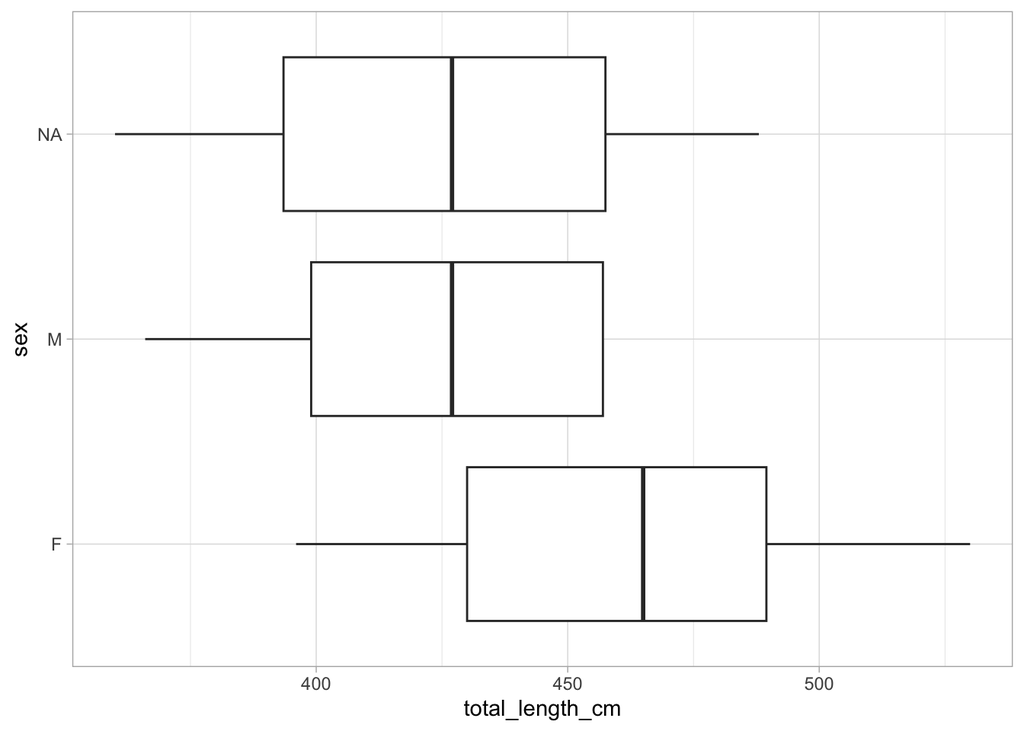

```r
white_sharks%>%
  ggplot(aes(x=total_length_cm, y=sex))+
  geom_boxplot()+
  theme_light()
```

13. (2 points) Using the `sharks` or the `white_sharks` data, what is one question that you are interested in exploring? Write the question and answer it using a plot or table.

# How big is the largest recorded white shark(in cm) in the data? Confirm that the sex of the shark is female.

```r
white_sharks%>%
  group_by(total_length_cm, sex)%>%
  count(total_length_cm)%>%
  arrange(desc(total_length_cm))
```

```
## # A tibble: 16 × 3
## # Groups:   total_length_cm, sex [16]
##    total_length_cm sex       n
##              <dbl> <chr> <int>
##  1             530 F         1
##  2             490 F         1
##  3             488 F         1
##  4             488 <NA>      1
##  5             457 M         4
##  6             450 M         1
##  7             442 F         1
##  8             427 M         2
##  9             427 <NA>      1
## 10             426 F         1
## 11             402 M         1
## 12             396 F         1
## 13             396 M         1
## 14             380 M         1
## 15             366 M         1
## 16             360 <NA>      1
```

#The largest shark was in fact a female and she was 530cm.